# Super-resolution with PyTorch

## Results

[figure not shown]

[figure not shown]

## Results

[figure not shown]

[figure not shown]

## Results

[figure not shown]

[figure not shown]

## Results

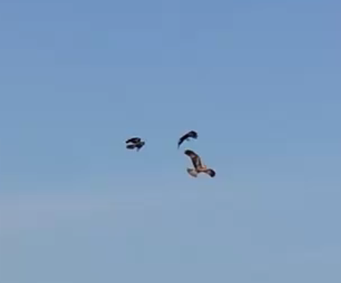

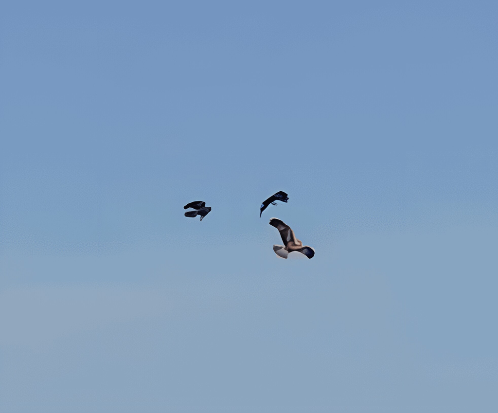

## Results

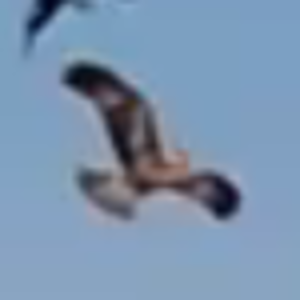

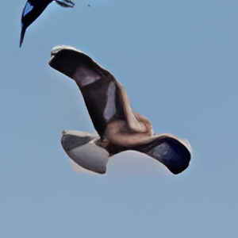

## Metrics

We could use the [PSNR and SSIM implementations from SwinIR](https://github.com/JingyunLiang/SwinIR/blob/main/utils/util_calculate_psnr_ssim.py), but let’s try the [Kornia](https://kornia.readthedocs.io/en/latest/index.html) functions we mentioned earlier:

- kornia.metrics.psnr
- kornia.metrics.ssim

## Metrics

Let’s load the libraries we need:

```python
import kornia
from PIL import Image
import torch
from torchvision.transforms import v2
```

## Metrics

Then, we load one pair of images (LR and HR):

```python
berlin1_lr = Image.open("<some/path>/lr/berlin_1945_1.jpg")
berlin1_hr = Image.open("<some/path>/hr/berlin_1945_1.png")
```

We can display these images with:

```python
berlin1_lr.show()
berlin1_hr.show()
```

## Metrics

Now, we need to resize them so that they have identical dimensions and turn them into tensors:

```python
preprocess = v2.Compose([
        v2.Resize(256),
        v2.ToImage(),
        v2.ToDtype(torch.float32, scale=True)
        ])

berlin1_lr_t = preprocess(berlin1_lr)
berlin1_hr_t = preprocess(berlin1_hr)
```

## Metrics

```python
berlin1_lr_t.shape
berlin1_hr_t.shape
```

```
torch.Size([3, 267, 256])
torch.Size([3, 267, 256])
```

We now have tensors with 3 dimensions:

- the channels (RGB)
- the height of the image (in pixels)
- the width of the image (in pixels)

## Metrics

As data processing is done in batch in ML, we need to add a 4th dimension: the **batch size**

(It will be equal to `1` since we have a batch size of a single image)

```python
batch_berlin1_lr_t = torch.unsqueeze(berlin1_lr_t, 0)
batch_berlin1_hr_t = torch.unsqueeze(berlin1_hr_t, 0)
```

## Metrics

Our new tensors are now ready:

```python
batch_berlin1_lr_t.shape
batch_berlin1_hr_t.shape
```

```
torch.Size([1, 3, 267, 256])
torch.Size([1, 3, 267, 256])
```

## PSNR

```python
psnr_value = kornia.metrics.psnr(batch_berlin1_lr_t, batch_berlin1_hr_t, max_val=1.0)
psnr_value.item()
```

```
33.379642486572266
```

## SSIM

```python
ssim_map = kornia.metrics.ssim(
    batch_berlin1_lr_t, batch_berlin1_hr_t, window_size=5, max_val=1.0, eps=1e-12)

ssim_map.mean().item()
```

```
0.9868119359016418
```